# 上級マクロ経済学II

第2回 ソローモデルと収束

Author

荻巣嘉高

# 1 ソローモデル

## ソローモデルの概要

- 上級マクロ経済学Iでやっている（はず）
- 経済成長理論
  - **ソローモデル**
  - AKモデル
  - ラムゼイモデル
- 家計と企業が存在．
  - プレーンなモデルでは政府はなし．
- この講義では，離散時間で考えます．

## 家計

- 無限期間生存．
- 所得の$s$だけの割合を貯蓄．
- 非弾力的に労働供給を行う．
  - 労働力は$L_t$．
- 資本を保有しており，企業に貸し出す．
  - 資本（または資本ストック）は$K_t$．

## 企業

- 家計から労働，資本を借りて**一般財**を生産．
  - 生産量は$Y_t$
  - 一般財：消費も貯蓄もできて，投資すると資本としても使える財．
- 生産関数は$F(K_t, L_t)$で表され，規模に関して収穫一定．
  - **規模に関して収穫一定**：$F$が一次同次関数．
  - $F$は生産技術（technology）とか言われることもある．
  - $L_t$，$K_t$について増加関数ただし2階微分は負．
- 労働1単位あたりに$w_t$だけの賃金を支払う．
- 資本1単位あたりに$r_t$だけの利子を支払う．

## 家計の行動

- 家計は所得のうち$s$だけ貯蓄するので，貯蓄を$S_t$とすると，
  $$S_t = s Y_t$$
- 消費$C_t$は
  $$\begin{aligned}
  C_t = (1-s) Y_t
  \end{aligned}$$

## 企業の行動

- 代表的企業は生産関数$F$のもとで，資本$K_t$単位と労働$L_t$単位を使い，$Y_t$単位の財を生産する．
  $$Y_t = F(K_t, L_t)$$
- 毎期$I_t$だけ投資．
  - 投資：生産のための資本財を購入すること．
- 資本は毎期，$\delta$の割合で減耗．
  - $\delta$：資本減耗率． 次期の資本を決める，**資本の蓄積方程式**は．
    $$K_{t+1} = I_t + K_t - \delta K_t$$
    あるいは，$\Delta K_t \equiv K_{t+1} - K_t$を使って，
    $$\Delta K_{t} = I_t - \delta K_t$$

## 市場均衡

$$I_t = S_t$$
であるとき，市場が均衡（財市場の均衡）．

- ソローモデルでは均衡を常に分析．
  - ちなみに，資本市場と労働市場も均衡していることを暗に仮定している．
  - あるいは，資本市場，労働市場は存在せず，家計が企業を保有していると仮定しても良い．

$S_t = sY_t=sF(K_t,L_t)$であることを使えば，資本の蓄積方程式は次のように書き換えられる．
$$K_{t+1} = sY_t + K_t - \delta K_t ~ \Longleftrightarrow ~ \Delta K_t = sY_t - \delta K_t$$
あるいは，
$$K_{t+1} = sF(K_t, L_t) + K_t - \delta K_t ~ \Longleftrightarrow ~ \Delta K_{t} = sF(K_t, L_t) - \delta K_t$$

## 経済変数の動態

$$\begin{aligned}
K_{t+1} &= sF(K_t, L_t) + K_t - \delta K_t \\
L_{t+1} &= (1+n) L_t
\end{aligned}$$

- $n$：人口成長率．

初期時点の資本$K_0>0$と労働$L_0>0$が与えられれば，モデルは閉じる．

- $K_t$，$L_t$の動態に沿って，$Y_t=(K_t, L_t)$も動いていく．
- 2変数の差分方程式．
  - 一次同次の生産関数の性質を使えば，1変数の差分方程式にできる．
    - 分析で簡単に取り扱える．

## 一人当たり資本・生産

$k_t \equiv K_t/ L_t$：一人当たり資本

$y_t\equiv Y_t/ L_t = F(k,1) \equiv f(k_t)$：一人当たり生産/一人当たり所得

$$k_{t+1} = \frac{sf(k_t) + (1 - \delta) k_t}{1+n}$$
あるいは，$\Delta k_t \equiv k_{t+1} - k_t$を使って，
$$\Delta k_t = \frac{sf(k_t) - (\delta + n)k_t}{1+n}$$
動学方程式は，$k_t$のみの1変数差分方程式になった．

## 一人当たり変数の動態

$$\Delta k_t = \frac{sf(k_t) - (\delta + n)k_t}{1+n}$$

**Note**

- $\Delta k_t >0$:
  - $k_{t+1} > k_{t}$なので，今期から次期にかけて，資本が成長．
- $\Delta k_t <0$:
  - $k_{t+1} < k_{t}$なので，今期から次期にかけて，資本が減少．
- $\Delta k_t =0$:
  - $k_{t+1} = k_{t}$なので，今期から次期にかけて，資本は不変．
  - このとき，経済が**定常状態**にある．
- $1+n >0$なので，$sf(k_t) - (\delta + n)k_t$の符号がわかれば良い．

## 一人当たり成長率

一人当たり資本の成長率を$g_k$，一人当たりGDPの成長率を$g_y$とすると，
$$\begin{aligned}
g_k &= \frac{\Delta k_t}{k_t} \\
g_k &= \frac{\Delta y_t}{y_t} = \frac{y_{t+1} - y_t}{y_t} = \frac{f(k_{t+1}) - f(k_t)}{f(k_t)} \\
\end{aligned}$$

## 定常状態を描写

定常状態は
$$k_t = k_{t+1} = k^\ast$$
のとき．

そのときは，
$$s f(k^\ast) = (\delta + n) k^\ast$$

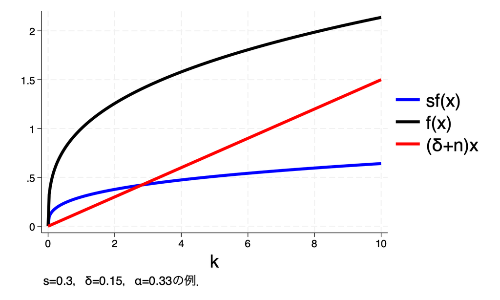

## コブ・ダグラス型生産関数

$$F(K_t, L_t) = A K_t^{\alpha} L_t^{1-\alpha}, ~ (0<\alpha<1)$$
を仮定して今後は議論．

- $A$：全要素生産性（Total Factor Productivity, TFP）
- $\alpha$: 資本の弾力性パラメーター，あるいは，資本分配率．

一人当たり生産は，
$$f(k_t) = A k_t^{\alpha}$$

定常状態の$k^{\ast}$は，
$$k^{\ast} = \left( \frac{sA}{\delta + n} \right)^{\frac{1}{1-\alpha}}$$

## 一人当たり資本の成長率と定常状態

一人当たり資本の成長率は，
$$\begin{aligned}
g_k &= \frac{sAk_t^{\alpha} - (\delta + n)k_t}{(1+n)k_t}
\end{aligned}$$

- 定常状態$\Delta k_t = 0$であれば，当然$g_k = \Delta k_t / k_t = 0$．

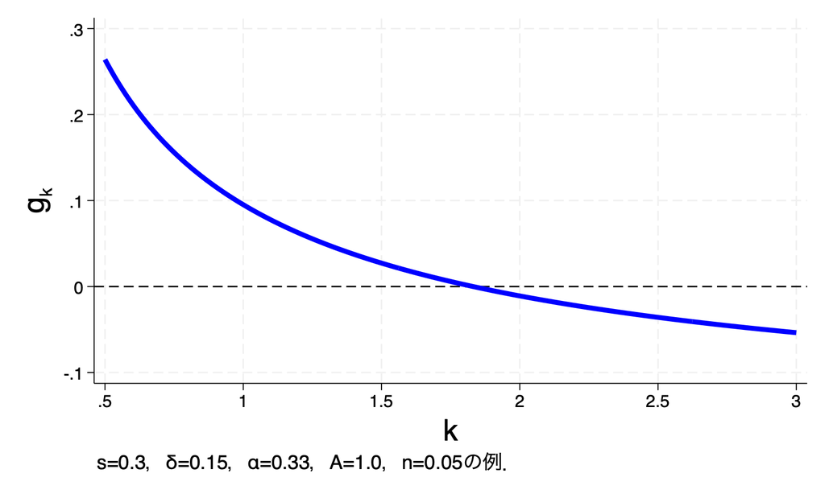

## 一人当たり所得の成長率と定常状態

一人当たりの成長率は，
$$\begin{aligned}
g_y &= \frac{k_{t+1}^{\alpha} - k_{t}^{\alpha}}{k_t^{\alpha}} \\
&= \left( \frac{k_{t+1}}{k_t} \right)^{\alpha} - 1 \\
&= (1+g_k)^{\alpha} - 1 \\
&= \left[ \frac{sAk_t^{\alpha} +(1-\delta)k_t}{(1+n)k_t} \right]^{\alpha} - 1
\end{aligned}$$

- 定常状態$\Delta k_t = 0$であれば$g_k= 0$なので，$g_y=0$．

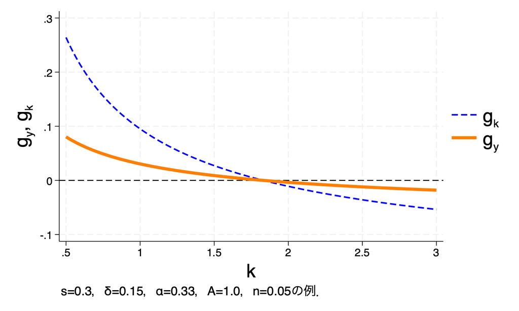

## 経済成長への含意（ソローモデル）

**絶対的収束**

- ソローモデルは，定常状態において，$k_t$の成長率はゼロ．
  - それに伴い$y_t$の成長率もゼロ．
- 定常状態は一意（ひとつだけ）．
  - どんな$k_t$からスタートしても，最終的に辿り着く$k^{\ast}$は同じ．
- 定常状態から離れている経済ほど，成長率が高い．
  - 発展途上国のキャッチアップ．

## 実証的な観測

一人当たりの所得水準を

- low（0 - 10,000 US$）
- middle（10,000 - 20,000 US$）
- high (20,000 - US$)

で色分けしてプロット

- 低所得から高所得へスムーズに推移していく成長経路に見えるか？

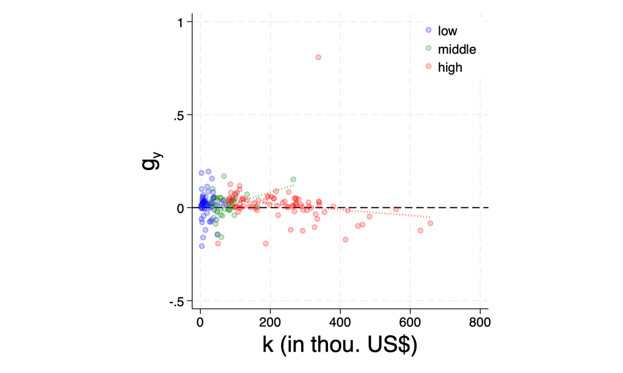

## サブサンプル

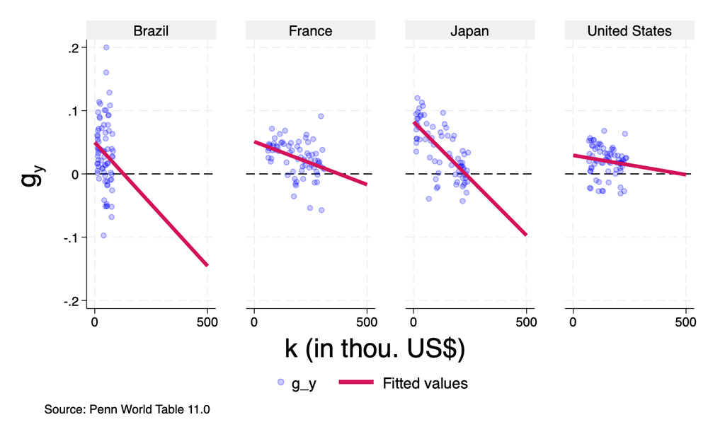

## 定常状態の予測値（$\hat{k}^{\ast}$）

| Brazil | France | Japan | US |
| --- | --- | --- | --- |
| 127.4 | 375.8 | 229.1 | 480.7 |

- どうやらたどり着く先は異なりそう．
- 収束までのスピードも違いそう．

## 成長への含意を修正

**条件付き収束**

- ソローモデルは，定常状態において，$k_t$の成長率はゼロ．
  - それに伴い$y_t$の成長率もゼロ．
- 定常状態は**あるパラメータセットに対して**一意（ひとつだけ）．
  - どんな$k_t$からスタートしても，**同じパラメータセットを持つ国なら**最終的に辿り着く$k^{\ast}$は同じ．
- 定常状態から離れている経済ほど，成長率が高い．
  - 発展途上国のキャッチアップ．

## ソローモデルのパラメータ変化

- $s$の変化で$g_y$曲線がシフト．
  - 定常状態の$k^{\ast}$の値が変化．
- その他のパラメータ$A$，$\alpha$などの変化がどのような変化をもたらす？

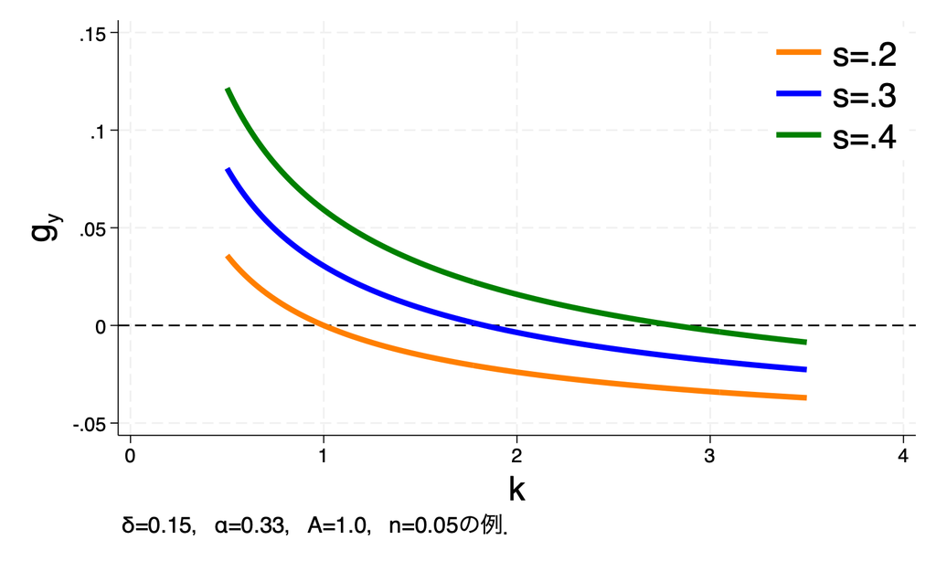